# Reproducible Research: Peer Assessment 1

Albert de Roos

2016-03-03

```r
library(dplyr)
Sys.setlocale("LC_TIME", "English")
```

## Loading and preprocessing the data

The data file was unzipped using read.csv and the column with the dates was set to Date format. In order to get English-named weekdays, the locale on the machine was set to English_United States.1252

```r
myrepdata <- read.csv("activity.csv")
myrepdata$date <- as.Date(myrepdata$date)
str(myrepdata)
```

```
## 'data.frame':    17568 obs. of  3 variables:
##  $ steps   : int  NA NA NA NA NA NA NA NA NA NA ...
##  $ date    : Date, format: "2012-10-01" "2012-10-01" ...
##  $ interval: int  0 5 10 15 20 25 30 35 40 45 ...
```

## What is mean total number of steps taken per day?

In order to calculate the mean and median steps per day, first the data is grouped by the day and the sum per day is derived.

```r
stepsperday <- myrepdata %>% group_by(date) %>% summarize(sum = sum(steps))
str(stepsperday)
```

```
## Classes 'tbl_df', 'tbl' and 'data.frame':    61 obs. of  2 variables:
##  $ date: Date, format: "2012-10-01" "2012-10-02" ...
##  $ sum : int  NA 126 11352 12116 13294 15420 11015 NA 12811 9900 ...
```

This yields a new data frame with 61 days consistent with the number of days in the 2 months of the data collection. The histogram of the steps taken per day and the mean and median are shown below.

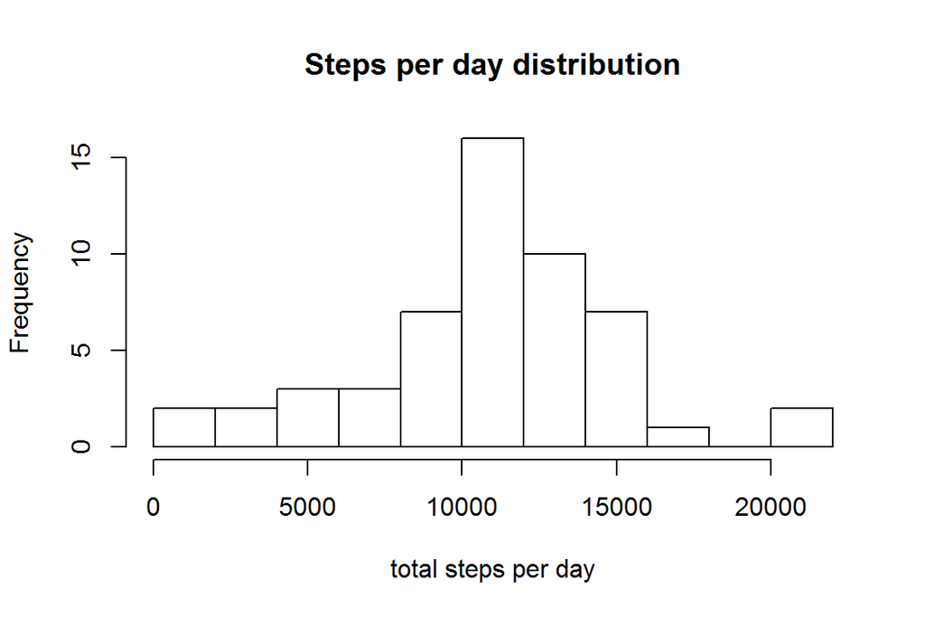

```r
hist(stepsperday$sum, breaks = 15, xlab = "total steps per day", main = "Steps per day distribution")
```

```r
summary(stepsperday$sum)
```

```
##    Min. 1st Qu.  Median    Mean 3rd Qu.    Max.    NA's
##      41    8841   10760   10770   13290   21190       8
```

## What is the average daily activity pattern?

For the average daily activity pattern, we group we data by time interval and then take the average of each time interval. We remove the NAN when we take the average. From the graph below we see the average daily pattern and below that, the interval where we see the highest average steps.

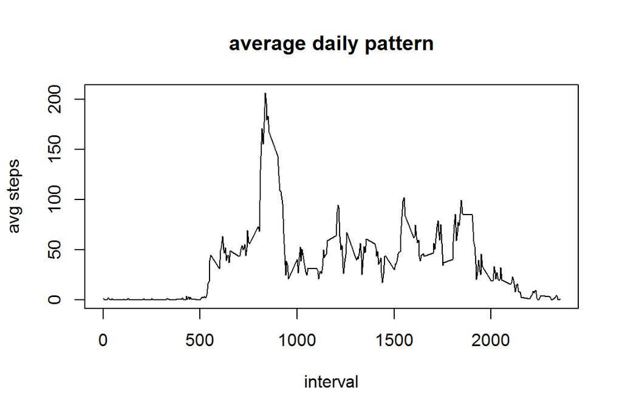

```r
stepsperinterval <- myrepdata %>%  group_by(interval) %>% summarize(avgsteps = mean(steps, na.rm = TRUE))
plot(stepsperinterval$interval, stepsperinterval$avgsteps, type = "l", main = "average daily pattern", xlab = "interval", ylab = "avg steps")
```

```r
stepsperinterval[which.max(stepsperinterval$avgsteps), ]
```

```
## Source: local data frame [1 x 2]
##
##   interval avgsteps
##      (int)    (dbl)
## 1      835 206.1698
```

## Are there differences in activity patterns between weekdays and weekends?